# 서울시 로컬브랜드 골목상권 분석 프로젝트 (Clustering Part)

## 5. 모델링 : K-Means Algorithm

### 5.1 Building the Model : k 값을 정합니다.

```python
import warnings
warnings.filterwarnings('ignore')
```

```python
from sklearn.cluster import KMeans
WCSS=[]
```

```python
WCSS
```

```
[]
```

관성을 의미하는 inertia 는 데이터들이 얼마나 응집되어 있는 가에 대해 나타낸다.

데이터로 부터 자신이 속한 군집의 중심까지의 거리를 의미하므로 이 값이 낮을 수록 군집화가 이뤄진 것으로 볼 수 있다.

```python
for i in range (1,11):
    kmeans = KMeans(n_clusters=i, init='k-means++', random_state=0)
    kmeans.fit(X)
    interia=kmeans.inertia_
    print('k:', i, 'inertia:', interia)
    WCSS.append(kmeans.inertia_)
```

```
k: 1 inertia: 1065717893244305.6
k: 2 inertia: 300678330157811.56
k: 3 inertia: 109916777016794.47
k: 4 inertia: 36555547789206.5
k: 5 inertia: 19184199630589.69
k: 6 inertia: 10980338305576.52
k: 7 inertia: 7625761942904.667
k: 8 inertia: 4980606991573.758
k: 9 inertia: 2920697889906.1245
k: 10 inertia: 938357851858.8713
```

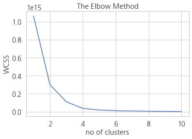

```python
plt.plot(range(1,11), WCSS)

plt.title('The Elbow Method')
plt.xlabel('no of clusters')
plt.ylabel('WCSS')
plt.show()
```

```python
##Finally, we got that k=4
```

```python
kmeansmodel = KMeans(n_clusters=4, init='k-means++', max_iter=300, random_state=0)
y_kmeans= kmeansmodel.fit_predict(X)
y_kmeans
```

```
array([3, 2, 2, 3, 2, 1, 1, 1, 3, 3, 3, 2, 0, 0, 0, 0])
```

WCSS가 감소하면서 k값이 더 이상 변화하지 않는 구간이 4이므로 군집을 4로 나누기로 결정했다.

```python
X[0:3,]
```

```
array([[4.08700000e+03, 1.05726121e+07],
       [4.20700000e+03, 1.70113228e+07],
       [4.43900000e+03, 1.70690021e+07]])
```

```python
XX.head(3)
```

|  | Population | Average_Sales |
| --- | --- | --- |
| 0 | 4087 | 10572612.10 |
| 1 | 4207 | 17011322.83 |
| 2 | 4439 | 17069002.06 |

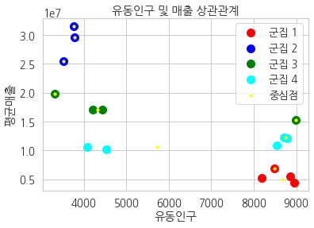

```python
plt.scatter(X[y_kmeans == 0, 0], X[y_kmeans == 0, 1], s = 100, c = 'red', label = '군집 1')
plt.scatter(X[y_kmeans == 1, 0], X[y_kmeans == 1, 1], s = 100, c = 'blue', label = '군집 2')
plt.scatter(X[y_kmeans == 2, 0], X[y_kmeans == 2, 1], s = 100, c = 'green', label = '군집 3')
plt.scatter(X[y_kmeans == 3, 0], X[y_kmeans == 3, 1], s = 100, c = 'cyan', label = '군집 4')
plt.scatter(kmeans.cluster_centers_[:, 0], kmeans.cluster_centers_[:, 1], s = 10, c = 'yellow', label = '중심점')

plt.title('유동인구 및 매출 상관관계')
plt.xlabel('유동인구')
plt.ylabel('평균매출')
plt.legend()
plt.show()
```

실행결과 유동인구가 많아도 평균매출이 낮은 군집 1 과 유동인구가 적어도 매출이 높은 군집2가 특이 하다는 것을 알 수 있었다.

이에 대해 알아보기 위해 군집1 지역과 군집2 지역이 어느 곳인지 알아보았다.

```python
y_kmeans
```

```
array([3, 2, 2, 3, 2, 1, 1, 1, 3, 3, 3, 2, 0, 0, 0, 0])
```

```python
X
```

```
array([[4.08700000e+03, 1.05726121e+07],
       [4.20700000e+03, 1.70113228e+07],
       [4.43900000e+03, 1.70690021e+07],
       [4.52600000e+03, 1.01764692e+07],
       [3.31100000e+03, 1.97727055e+07],
       [3.50900000e+03, 2.54423554e+07],
       [3.75800000e+03, 3.15618301e+07],
       [3.78100000e+03, 2.95320966e+07],
       [8.54500000e+03, 1.08725234e+07],
       [8.71800000e+03, 1.22647464e+07],
       [8.78700000e+03, 1.21602559e+07],
       [8.99500000e+03, 1.53157819e+07],
       [8.19300000e+03, 5.22217861e+06],
       [8.49400000e+03, 6.87216435e+06],
       [8.86200000e+03, 5.43218050e+06],
       [8.95200000e+03, 4.32814253e+06]])
```

```python
X[y_kmeans == 0, 0] ## 유동인구
```

```
array([8193., 8494., 8862., 8952.])
```

```python
XX[y_kmeans == 0] # 오류2동버들시장
```

|  | Population | Average_Sales |
| --- | --- | --- |
| 12 | 8193 | 5222178.611 |
| 13 | 8494 | 6872164.348 |
| 14 | 8862 | 5432180.500 |
| 15 | 8952 | 4328142.529 |

```python
X[y_kmeans == 0, 1] # 평균매출
```

```
array([5222178.611, 6872164.348, 5432180.5  , 4328142.529])
```

```python
XX[y_kmeans == 1]
```

|  | Population | Average_Sales |
| --- | --- | --- |
| 5 | 3509 | 25442355.42 |
| 6 | 3758 | 31561830.12 |
| 7 | 3781 | 29532096.59 |

```python
X[y_kmeans == 3, 1] ##선유도역 6번
```

```
array([10572612.1 , 10176469.24, 10872523.38, 12264746.43, 12160255.86])
```

확인 결과 유동인구는 많지만 매출이 적은 지역은 오류2동 버들시장이었고 유동인구는 적지만 매출이 많은 지역은 선유도역 6번 출구였다.

이를 통해 유동인구와 매출은 양의 상관관계를 가지고 있지 않고 각 지역마다 환경적 특징에 따라 환경분석을 진행하였다. (연령대,집객시설)